# Load and Analyse Truro Network

Valentin Lucet & Imogen Hobbs

28/12/2021

# Load libraries

```r
library(readxl)
library(Rgraphviz)
library(bnlearn)
```

# Read in data

```r
# The path to data is relative to where the mrd file is located
excel_path <- "../data/Markov_Blankets.xlsx"
# excel_path <- "/Users/imogenhobbs/Library/Mobile Documents/com~apple~CloudDocs/Theme 1 ResNet/MSc_Renewable_Resources/R/data/2Markov_Blankets.xlsx"

# Get all the sheet names
sheet_vector <- excel_sheets(excel_path)

# Apply the read_excel function too all the sheets
dat_list <- mapply(FUN = read_excel, path =excel_path,
                   sheet = sheet_vector)
names(dat_list) <- sheet_vector

# Split the names of the sheets to get info on the variables
sheet_vector_clean_split <-
  sapply(sheet_vector, function(x) {
    if(grepl("and", x)) strsplit(x, "_and_", fixed = T) else x})

str(dat_list)
```

```
## List of 9
##  $ HD                        : tibble [2 × 2] (S3: tbl_df/tbl/data.frame)
##   ..$ ...1       : chr [1:2] "Expansion" "Return_to_Marshland"
##   ..$ Probability: num [1:2] 0.1 0.9
##  $ EW                        : tibble [2 × 2] (S3: tbl_df/tbl/data.frame)
##   ..$ ...1       : chr [1:2] "Above_Average_EW" "Below_Average_EW"
##   ..$ Probability: num [1:2] 0.75 0.25
##  $ FC                        : tibble [2 × 2] (S3: tbl_df/tbl/data.frame)
##   ..$ ...1       : chr [1:2] "Above_Average_FC" "Below_Average_FC"
##   ..$ Probability: num [1:2] 0.1 0.9
##  $ MAR                       : tibble [2 × 2] (S3: tbl_df/tbl/data.frame)
##   ..$ ...1       : chr [1:2] "Present_MAR" "Absent_MAR"
##   ..$ Probability: num [1:2] 0.95 0.05
##  $ DMK                       : tibble [2 × 2] (S3: tbl_df/tbl/data.frame)
##   ..$ ...1         : chr [1:2] "High_DMK" "Low_DMK"
##   ..$ Probabilities: num [1:2] 0.2 0.8
##  $ IJ_and_HD                 : tibble [2 × 3] (S3: tbl_df/tbl/data.frame)
##   ..$ ...1               : chr [1:2] "Above_Average_IJ" "Below_Average_IJ"
##   ..$ Expansion          : num [1:2] 0.7 0.3
##   ..$ Return_to_Marshland: num [1:2] 0.3 0.7
##  $ TID_and_EW_and_MAR        : tibble [2 × 5] (S3: tbl_df/tbl/data.frame)
##   ..$ ...1                        : chr [1:2] "Above_Average_TID" "Below_Average_TID"
##   ..$ Above_Average_EW:Present_MAR: num [1:2] 0.35 0.65
##   ..$ Below_Average_EW:Present_MAR: num [1:2] 0.2 0.8
##   ..$ Above_Average_EW:Absent_MAR : num [1:2] 0.45 0.55
##   ..$ Below_Average_EW:Absent_MAR : num [1:2] 0.3 0.7
##  $ DMNT_and_FC_and_DMK       : tibble [2 × 5] (S3: tbl_df/tbl/data.frame)
##   ..$ ...1                     : chr [1:2] "Maintained" "Removed"
##   ..$ Above_Average_FC:High_DMK: num [1:2] 0.3 0.7
##   ..$ Above_Average_FC:Low_DMK : num [1:2] 0.5 0.5
##   ..$ Below_Average_FC:High_DMK: num [1:2] 0.3 0.7
##   ..$ Below_Average_FC:Low_DMK : num [1:2] 0.6 0.4
##  $ FL_and_IJ_and_TID_and_DMNT: tibble [2 × 9] (S3: tbl_df/tbl/data.frame)
##   ..$ ...1                                         : chr [1:2] "Above_Average_FL" "Below_Average_FL"
##   ..$ Above_Average_IJ:Above_Average_TID:Maintained: num [1:2] 0.4 0.6
##   ..$ Above_Average_IJ:Below_Average_TID:Maintained: num [1:2] 0.5 0.5
##   ..$ Below_Average_IJ:Above_Average_TID:Maintained: num [1:2] 0.5 0.5
##   ..$ Below_Average_IJ:Below_Average_TID:Maintained: num [1:2] 0.3 0.7
##   ..$ Above_Average_IJ:Above_Average_TID:Removed   : num [1:2] 0.5 0.5
##   ..$ Above_Average_IJ:Below_Average_TID:Removed   : num [1:2] 0.4 0.6
##   ..$ Below_Average_IJ:Above_Average_TID:Removed   : num [1:2] 0.4 0.6
##   ..$ Below_Average_IJ:Below_Average_TID:Removed   : num [1:2] 0.2 0.8
```

```r
print(sheet_vector_clean_split)
```

```
## $HD
## [1] "HD"
##
## $EW
## [1] "EW"
##
## $FC
## [1] "FC"
##
## $MAR
## [1] "MAR"
##
## $DMK
## [1] "DMK"
##
## $IJ_and_HD
## [1] "IJ" "HD"
##
## $TID_and_EW_and_MAR
## [1] "TID" "EW"  "MAR"
##
## $DMNT_and_FC_and_DMK
## [1] "DMNT" "FC"   "DMK"
##
## $FL_and_IJ_and_TID_and_DMNT
## [1] "FL"   "IJ"   "TID"  "DMNT"
```

# Wrangling data into CPTs

We want to transform the data into probability tables for bnlearn

```r
source("0_functions.R")
```

We apply the function `clean_tables` to all the sheets.

```r
cpt_list <- mapply(FUN = clean_tables,
                   tbl = dat_list,
                   element_names = sheet_vector_clean_split)
names(cpt_list) <- sapply(sheet_vector_clean_split, `[`, 1)
print(cpt_list)
```

```
## $HD
## HD
##           Expansion Return_to_Marshland
##                 0.1                 0.9
##
## $EW
## EW
## Above_Average_EW Below_Average_EW
##             0.75             0.25
##
## $FC
## FC
## Above_Average_FC Below_Average_FC
##              0.1              0.9
##
## $MAR
## MAR
## Present_MAR  Absent_MAR
##        0.95        0.05
##
## $DMK
## DMK
## High_DMK  Low_DMK
##      0.2      0.8
##
## $IJ
##                   HD
## IJ                 Expansion Return_to_Marshland
##   Above_Average_IJ       0.7                 0.3
##   Below_Average_IJ       0.3                 0.7
##
## $TID
## , , MAR = Present_MAR
##
##                    EW
## TID                 Above_Average_EW Below_Average_EW
##   Above_Average_TID             0.35              0.2
##   Below_Average_TID             0.65              0.8
##
## , , MAR = Absent_MAR
```

[output cut: 36 more lines]

```
##   Below_Average_FL              0.5              0.7
##
## , , TID = Above_Average_TID, DMNT = Removed
##
##                   IJ
## FL                 Above_Average_IJ Below_Average_IJ
##   Above_Average_FL              0.5              0.4
##   Below_Average_FL              0.5              0.6
##
## , , TID = Below_Average_TID, DMNT = Removed
##
##                   IJ
## FL                 Above_Average_IJ Below_Average_IJ
##   Above_Average_FL              0.4              0.2
##   Below_Average_FL              0.6              0.8
```

# Creating the network

We create the network with a string of symbols (see Scutari).

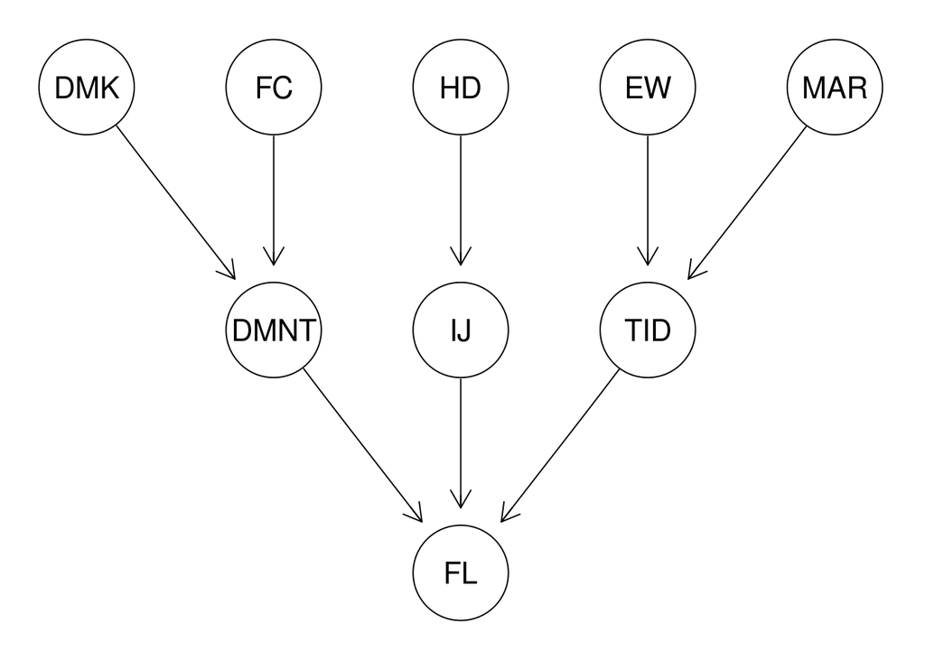

```r
network <- (model2network("[HD][MAR][IJ|HD][EW][TID|MAR:EW][FC][DMK][DMNT|FC:DMK][FL|IJ:TID:DMNT]"))
graphviz.plot(network)
```

# Fitting

We can now fit the network:

```r
bn <- bnlearn::custom.fit(network, cpt_list)
print(bn)
```

```
##
##   Bayesian network parameters
##
##   Parameters of node DMK (multinomial distribution)
##
## Conditional probability table:
##  DMK
## High_DMK  Low_DMK
##      0.2      0.8
##
##   Parameters of node DMNT (multinomial distribution)
##
## Conditional probability table:
##
## , , FC = Above_Average_FC
##
##             DMK
## DMNT         High_DMK Low_DMK
##   Maintained      0.3     0.5
##   Removed         0.7     0.5
##
## , , FC = Below_Average_FC
##
##             DMK
## DMNT         High_DMK Low_DMK
##   Maintained      0.3     0.6
##   Removed         0.7     0.4
##
##
##   Parameters of node EW (multinomial distribution)
##
## Conditional probability table:
##  EW
## Above_Average_EW Below_Average_EW
##             0.75             0.25
##
##   Parameters of node FC (multinomial distribution)
##
## Conditional probability table:
##  FC
```

[output cut: 61 more lines]

```
## Conditional probability table:
##
## , , MAR = Present_MAR
##
##                    EW
## TID                 Above_Average_EW Below_Average_EW
##   Above_Average_TID             0.35             0.20
##   Below_Average_TID             0.65             0.80
##
## , , MAR = Absent_MAR
##
##                    EW
## TID                 Above_Average_EW Below_Average_EW
##   Above_Average_TID             0.45             0.30
##   Below_Average_TID             0.55             0.70
```

# Belief Propagation

In order to use this network to help make decisions about future events, we need to use Belief Propagation. Belief Propagation can be done with Exact or Approximate Algorithms. Because this network is small (among other reasons), we are going to use an Exact Algorithm with Junction Trees. Junction Trees are are popular method of exact inference and exist in the gRain package.

Junction Trees require that the network be **moralised**, that is, an undirected graph, where each node is now connected to its Markov Blanket.

Let’s moralise our BN:

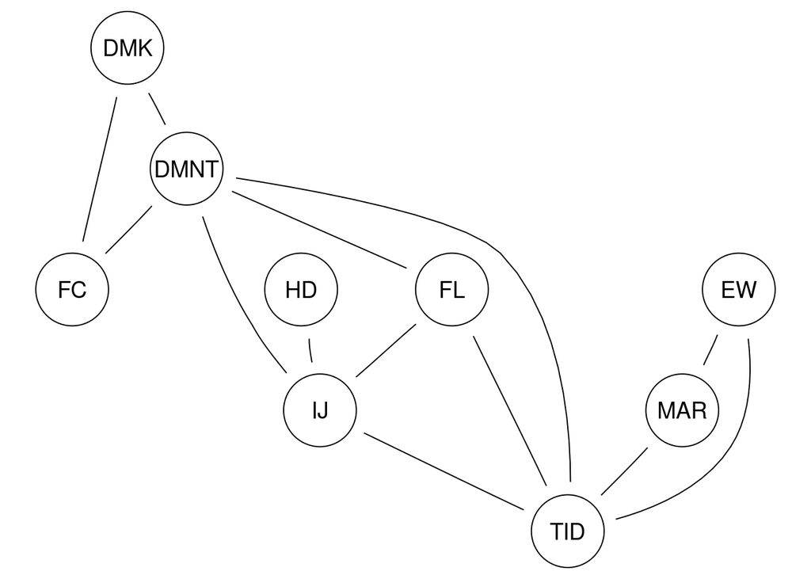

```r
graphviz.plot(moral(network))
```

And 3 Separators: S12 = {DMNT} S14= {DMNT} S23 = {TID, IJ}

The following section has quotes from Oxford Bayesian Analysis by Scutari (2017).

“First, we convert the BN from *bnlearn* to its equivalent in *gRain* with as.grain() and we construct the junction tree with compile()”

```r
library(gRain)
junction <- compile(as.grain(bn))
```

```r
jDMNT <- setEvidence(junction, nodes = "DMNT", states = "High")
```

“And after that, we can perform our conditional probability query with querygrain(), which also takes care of the belief propagation.”

```r
TIDxIJ.cpt <- querygrain(jDMNT, nodes = c("TID", "IJ"), type = "joint")
print(TIDxIJ.cpt)
```

```
##                   TID
## IJ                 Above_Average_TID Below_Average_TID
##   Above_Average_IJ           0.10795           0.23205
##   Below_Average_IJ           0.20955           0.45045
```

Let’s try it with Flood-risk (FL), with the evidence being set on different variables:

1. Decision maker knowledge:

```r
jDMK <- setEvidence(junction, nodes = "DMK", states = "High_DMK")
FLxDMKcpt <- querygrain(jDMK, nodes = c("FL"), type = "joint")
print(round(FLxDMKcpt, 2))
```

```
## FL
## Above_Average_FL Below_Average_FL
##             0.34             0.66
```

```r
jDMK2 <- setEvidence(junction, nodes = "DMK", states = "Low_DMK")
FLxDMKcpt2 <- querygrain(jDMK2, nodes = c("FL"), type = "joint")
print(round(FLxDMKcpt2, 2))
```

```
## FL
## Above_Average_FL Below_Average_FL
##             0.37             0.63
```

2. Human development:

```r
jHD <- setEvidence(junction, nodes = "HD", states = "Expansion")
FLxHDcpt <- querygrain(jHD, nodes = c("FL"), type = "joint")
print(round(FLxHDcpt, 2))
```

```
## FL
## Above_Average_FL Below_Average_FL
##             0.41             0.59
```

```r
jHD2 <- setEvidence(junction, nodes = "HD", states = "Return_to_Marshland")
FLxHDcpt2 <- querygrain(jHD2, nodes = c("FL"), type = "joint")
print(round(FLxHDcpt2, 2))
```

```
## FL
## Above_Average_FL Below_Average_FL
##             0.36             0.64
```

3. Dyke Maintenance

```r
jDMNT <- setEvidence(junction, nodes = "DMNT", states = "Maintained")
FLxDMNTcpt <- querygrain(jDMNT, nodes = c("FL"), type = "joint")
print(round(FLxDMNTcpt, 2))
```

```
## FL
## Above_Average_FL Below_Average_FL
##              0.4              0.6
```

```r
jDMNT2 <- setEvidence(junction, nodes = "DMNT", states = "Removed")
FLxDMNTcpt2 <- querygrain(jDMNT2, nodes = c("FL"), type = "joint")
print(round(FLxDMNTcpt2, 2))
```

```
## FL
## Above_Average_FL Below_Average_FL
##             0.32             0.68
```

4. Financial Constraints

```r
jFC <- setEvidence(junction, nodes = "FC", states = "Above_Average")
FLxFCcpt <- querygrain(jFC, nodes = c("FL"), type = "joint")
print(round(FLxFCcpt, 2))
```

```
## FL
## Above_Average_FL Below_Average_FL
##             0.36             0.64
```

```r
jFC2 <-setEvidence(junction, nodes = "FC", states = "Below_Average")
FLxFCcpt2 <- querygrain(jDMNT2, nodes = c("FL"), type = "joint")
print(round(FLxFCcpt2, 2))
```

```
## FL
## Above_Average_FL Below_Average_FL
##             0.32             0.68
```

5. Tide frequency

```r
jTF <- setEvidence(junction, nodes = "TID", states = "Above_Average_TID")
FLxTFcpt <- querygrain(jTF, nodes = c("FL"), type = "joint")
print(round(FLxTFcpt, 2))
```

```
## FL
## Above_Average_FL Below_Average_FL
##             0.45             0.55
```

```r
jTF2 <-setEvidence(junction, nodes = "TID", states = "Below_Average_TID")
FLxTFcpt2 <- querygrain(jTF2, nodes = c("FL"), type = "joint")
print(round(FLxTFcpt2, 2))
```

```
## FL
## Above_Average_FL Below_Average_FL
##             0.32             0.68
```

6. Saltmarsh status

```r
jMAR <- setEvidence(junction, nodes = "MAR", states = "Present_MAR")
FLxMARcpt <- querygrain(jMAR, nodes = c("FL"), type = "joint")
print(round(FLxMARcpt, 2))
```

```
## FL
## Above_Average_FL Below_Average_FL
##             0.36             0.64
```

```r
jMAR2 <-setEvidence(junction, nodes = "MAR", states = "Absent_MAR")
FLxMARcpt2 <- querygrain(jMAR2, nodes = c("FL"), type = "joint")
print(round(FLxMARcpt2, 2))
```

```
## FL
## Above_Average_FL Below_Average_FL
##             0.37             0.63
```

7. Extreme weather frequency

```r
jEW <- setEvidence(junction, nodes = "EW", states = "Above_Average_EW")
FLxEWcpt <- querygrain(jEW, nodes = c("FL"), type = "joint")
print(round(FLxEWcpt, 2))
```

```
## FL
## Above_Average_FL Below_Average_FL
##             0.37             0.63
```

```r
jEW2 <-setEvidence(junction, nodes = "EW", states = "Below_Average_EW")
FLxEWcpt2 <- querygrain(jEW2, nodes = c("FL"), type = "joint")
print(round(FLxEWcpt2, 2))
```

```
## FL
## Above_Average_FL Below_Average_FL
##             0.35             0.65
```

8. Ice Jam frequency

```r
jIJ <- setEvidence(junction, nodes = "IJ", states = "Above_Average_IJ")
FLxIJcpt <- querygrain(jIJ, nodes = c("FL"), type = "joint")
print(round(FLxIJcpt, 2))
```

```
## FL
## Above_Average_FL Below_Average_FL
##             0.45             0.55
```

```r
jIJ2 <- setEvidence(junction, nodes = "IJ", states = "Below_Average_IJ")
FLxIJcpt2 <- querygrain(jIJ2, nodes = c("FL"), type = "joint")
print(round(FLxIJcpt2, 2))
```

```
## FL
## Above_Average_FL Below_Average_FL
##             0.32             0.68
```

# Scenarios by permutations

```r
perms <- gtools::permutations(2, 8, repeats.allowed = T)
perms_list <- lapply(apply(perms, MARGIN = 1, list), unlist)

graph_list <- lapply(perms_list, FUN = generate_combination)
FL <- lapply(graph_list, function(x) c(querygrain(x, nodes = c("FL"))[[1]]))
scores <- unlist(lapply(FL, function(x) x[2]))
max_ids <- which(scores == max(scores))
percent <- (length(max_ids)/length(perms_list))*100

bests <- graph_list[max_ids]

# > length(bests)
# [1] 32
```

We find that 32 scenarios maximize below average flood risk. Lets look at their evidence.

```r
evidences <- lapply(bests, function(x) getEvidence(x))
evidences_dfs <- lapply(evidences, function(x){
  df <- as.data.frame(x)[, c("nodes", "hard_state")]
})
all_evidence <- dplyr::bind_rows(evidences_dfs)

all_evidence_ar <- as.data.frame(table(all_evidence)) %>%
    dplyr::arrange(desc(Freq), nodes, decreasing = F)

filtered <- all_evidence_ar %>%
  dplyr::mutate(imp = Freq/length(bests)*100) %>%
  dplyr::filter(Freq !=0)

print(filtered)
```

```
##    nodes          hard_state Freq imp
## 1   DMNT             Removed   32 100
## 2     IJ    Below_Average_IJ   32 100
## 3    TID   Below_Average_TID   32 100
## 4    DMK            High_DMK   16  50
## 5    DMK             Low_DMK   16  50
## 6     EW    Above_Average_EW   16  50
## 7     EW    Below_Average_EW   16  50
## 8     FC    Above_Average_FC   16  50
## 9     FC    Below_Average_FC   16  50
## 10    HD           Expansion   16  50
## 11    HD Return_to_Marshland   16  50
## 12   MAR          Absent_MAR   16  50
## 13   MAR         Present_MAR   16  50
```